# Actividad 1.8 Análisis Factorial II

Rey Iván De La Fuente Chávez

2026-09-03

# Preparación

Los datos contienen información sobre el consumo de combustible y distintas características de los automóviles. Para el análisis se utilizarán las variables cuantitativas y se eliminarán las observaciones con datos faltantes.

```r
library(MVN)
library(psych)
library(GPArotation)
library(knitr)

knitr::opts_chunk$set(
  echo = TRUE,
  warning = FALSE,
  message = FALSE
)
```

# 1. Lectura y limpieza de los datos

Primero se leen los datos, se asignan nombres descriptivos a las variables y se revisan los valores faltantes.

Posteriormente se eliminan las filas que tengan al menos un valor faltante.

```r
# Leer datos
datos <- read.csv(
  "C:\\Users\\reyiv\\Downloads\\cars93.csv",
  header = TRUE,
  na.strings = c("NA", "?", "")
)

# Asignar nombres
names(datos) <- c(
  "mpg",
  "cylinders",
  "mileage",
  "horsepower",
  "weight",
  "acceleration",
  "model_year",
  "origin",
  "car_name"
)

# Asegurar que horsepower sea numérica
datos$horsepower <- as.numeric(as.character(datos$horsepower))

# Origin representa categorías
datos$origin <- factor(datos$origin)

# Número original de observaciones
n_original <- nrow(datos)

# Valores faltantes
cat("Valores faltantes por variable:\n")
```

```
## Valores faltantes por variable:
```

```r
print(colSums(is.na(datos)))
```

```
##          mpg    cylinders      mileage   horsepower       weight acceleration
##            8            0            0            6            0            0
##   model_year       origin     car_name
##            0            0            0
```

```r
# Eliminar observaciones incompletas
datos <- na.omit(datos)

# Resumen de la limpieza
cat("\nObservaciones originales:", n_original)
```

```
##
## Observaciones originales: 406
```

```r
cat("\nObservaciones eliminadas:", n_original - nrow(datos))
```

```
##
## Observaciones eliminadas: 14
```

```r
cat("\nObservaciones finales:", nrow(datos), "\n")
```

```
##
## Observaciones finales: 392
```

```r
# Revisar estructura
str(datos)
```

```
## 'data.frame':    392 obs. of  9 variables:
##  $ mpg         : num  18 15 18 16 17 15 14 14 14 15 ...
##  $ cylinders   : int  8 8 8 8 8 8 8 8 8 8 ...
##  $ mileage     : num  307 350 318 304 302 429 454 440 455 390 ...
##  $ horsepower  : num  130 165 150 150 140 198 220 215 225 190 ...
##  $ weight      : int  3504 3693 3436 3433 3449 4341 4354 4312 4425 3850 ...
##  $ acceleration: num  12 11.5 11 12 10.5 10 9 8.5 10 8.5 ...
##  $ model_year  : int  70 70 70 70 70 70 70 70 70 70 ...
##  $ origin      : Factor w/ 3 levels "1","2","3": 1 1 1 1 1 1 1 1 1 1 ...
##  $ car_name    : chr  "chevrolet chevelle malibu" "buick skylark 320" "plymouth satellite" "amc rebel sst" ...
##  - attr(*, "na.action")= 'omit' Named int [1:14] 11 12 13 14 15 18 39 40 134 338 ...
##   ..- attr(*, "names")= chr [1:14] "11" "12" "13" "14" ...
```

```r
# Primeras filas
head(datos)
```

```
##   mpg cylinders mileage horsepower weight acceleration model_year origin
## 1  18         8     307        130   3504         12.0         70      1
## 2  15         8     350        165   3693         11.5         70      1
## 3  18         8     318        150   3436         11.0         70      1
## 4  16         8     304        150   3433         12.0         70      1
## 5  17         8     302        140   3449         10.5         70      1
## 6  15         8     429        198   4341         10.0         70      1
##                    car_name
## 1 chevrolet chevelle malibu
## 2         buick skylark 320
## 3        plymouth satellite
## 4             amc rebel sst
## 5               ford torino
## 6          ford galaxie 500
```

La base original tenía 406 observaciones. Se eliminaron 14 filas con valores faltantes, quedando 392 observaciones completas para realizar los análisis posteriores.

# 2. Matriz únicamente de variables numéricas

Las variables `origin` y `car_name` no se incluyen. Aunque `origin` originalmente utiliza números, estos solamente representan categorías y no cantidades numéricas.

Por lo tanto, la matriz de análisis contiene siete variables cuantitativas.

```r
M1 <- datos[, c(
  "mpg",
  "cylinders",
  "mileage",
  "horsepower",
  "weight",
  "acceleration",
  "model_year"
)]

# Revisar estructura
str(M1)
```

```
## 'data.frame':    392 obs. of  7 variables:
##  $ mpg         : num  18 15 18 16 17 15 14 14 14 15 ...
##  $ cylinders   : int  8 8 8 8 8 8 8 8 8 8 ...
##  $ mileage     : num  307 350 318 304 302 429 454 440 455 390 ...
##  $ horsepower  : num  130 165 150 150 140 198 220 215 225 190 ...
##  $ weight      : int  3504 3693 3436 3433 3449 4341 4354 4312 4425 3850 ...
##  $ acceleration: num  12 11.5 11 12 10.5 10 9 8.5 10 8.5 ...
##  $ model_year  : int  70 70 70 70 70 70 70 70 70 70 ...
```

```r
# Dimensiones
cat("Número de observaciones:", nrow(M1), "\n")
```

```
## Número de observaciones: 392
```

```r
cat("Número de variables:", ncol(M1), "\n")
```

```
## Número de variables: 7
```

```r
head(M1)
```

```
##   mpg cylinders mileage horsepower weight acceleration model_year
## 1  18         8     307        130   3504         12.0         70
## 2  15         8     350        165   3693         11.5         70
## 3  18         8     318        150   3436         11.0         70
## 4  16         8     304        150   3433         12.0         70
## 5  17         8     302        140   3449         10.5         70
## 6  15         8     429        198   4341         10.0         70
```

La matriz reducida contiene 392 observaciones y 7 variables numéricas. Esta será la matriz utilizada en los análisis multivariados siguientes.

# 3. Normalidad multivariada

Para comprobar la normalidad multivariada se utiliza la prueba de Mardia.

Las hipótesis son:

$$H_0: \text{Los datos provienen de una distribución normal multivariada}$$

$$H_1: \text{Los datos no provienen de una distribución normal
multivariada}$$

Se utiliza un nivel de significancia de:

$$\alpha = 0.05$$

```r
resultado_mardia <- MVN::mvn(
  data = M1,
  mvn_test = "mardia",
  univariate_test = "SW"
)

# Normalidad multivariada
resultado_mardia$multivariate_normality
```

```
##              Test Statistic p.value     Method          MVN
## 1 Mardia Skewness   980.306  <0.001 asymptotic ✗ Not normal
## 2 Mardia Kurtosis    18.029  <0.001 asymptotic ✗ Not normal
```

```r
# Normalidad individual
resultado_mardia$univariate_normality
```

```
##           Test     Variable Statistic p.value    Normality
## 1 Shapiro-Wilk          mpg     0.967  <0.001 ✗ Not normal
## 2 Shapiro-Wilk    cylinders     0.751  <0.001 ✗ Not normal
## 3 Shapiro-Wilk      mileage     0.882  <0.001 ✗ Not normal
## 4 Shapiro-Wilk   horsepower     0.904  <0.001 ✗ Not normal
## 5 Shapiro-Wilk       weight     0.941  <0.001 ✗ Not normal
## 6 Shapiro-Wilk acceleration     0.992   0.031 ✗ Not normal
## 7 Shapiro-Wilk   model_year     0.947  <0.001 ✗ Not normal
```

En la prueba de Mardia, tanto la asimetría como la curtosis presentan valores p menores a 0.001. Como estos valores son menores que 0.05, se rechaza $H_0$. Por lo tanto, los datos no cumplen con el supuesto de normalidad multivariada.

Las pruebas de Shapiro-Wilk también indican que ninguna de las siete variables cumple individualmente con normalidad al nivel de significancia de 0.05.

# 4. Correlación entre las variables

## 4.a Correlaciones por pares

Se calcula la matriz de correlaciones de Pearson y los valores p correspondientes.

Para determinar significancia estadística se utiliza:

$$\alpha = 0.01$$

Una correlación será considerada significativa cuando su valor p sea menor a 0.01.

```r
resultado_cor <- psych::corr.test(
  M1,
  method = "pearson",
  adjust = "none"
)

# Matriz de correlaciones
R <- resultado_cor$r

# Matriz de valores p
P <- resultado_cor$p

# Mostrar correlaciones
knitr::kable(
  round(R, 3),
  caption = "Matriz de correlaciones de Pearson"
)
```

Matriz de correlaciones de Pearson

|  | mpg | cylinders | mileage | horsepower | weight | acceleration | model_year |
| --- | --- | --- | --- | --- | --- | --- | --- |
| mpg | 1.000 | -0.778 | -0.805 | -0.778 | -0.832 | 0.423 | 0.581 |
| cylinders | -0.778 | 1.000 | 0.951 | 0.843 | 0.898 | -0.505 | -0.346 |
| mileage | -0.805 | 0.951 | 1.000 | 0.897 | 0.933 | -0.544 | -0.370 |
| horsepower | -0.778 | 0.843 | 0.897 | 1.000 | 0.865 | -0.689 | -0.416 |
| weight | -0.832 | 0.898 | 0.933 | 0.865 | 1.000 | -0.417 | -0.309 |
| acceleration | 0.423 | -0.505 | -0.544 | -0.689 | -0.417 | 1.000 | 0.290 |
| model_year | 0.581 | -0.346 | -0.370 | -0.416 | -0.309 | 0.290 | 1.000 |

```r
# Mostrar valores p
knitr::kable(
  round(P, 4),
  caption = "Matriz de valores p"
)
```

Matriz de valores p

|  | mpg | cylinders | mileage | horsepower | weight | acceleration | model_year |
| --- | --- | --- | --- | --- | --- | --- | --- |
| mpg | 0 | 0 | 0 | 0 | 0 | 0 | 0 |
| cylinders | 0 | 0 | 0 | 0 | 0 | 0 | 0 |
| mileage | 0 | 0 | 0 | 0 | 0 | 0 | 0 |
| horsepower | 0 | 0 | 0 | 0 | 0 | 0 | 0 |
| weight | 0 | 0 | 0 | 0 | 0 | 0 | 0 |
| acceleration | 0 | 0 | 0 | 0 | 0 | 0 | 0 |
| model_year | 0 | 0 | 0 | 0 | 0 | 0 | 0 |

Todas las correlaciones entre pares resultaron significativas con $\alpha=0.01$.

Se observan varias relaciones fuertes. Por ejemplo, `cylinders` y `mileage` tienen una correlación de 0.951, mientras que `mileage` y `weight` tienen una correlación de 0.933. Por otro lado, `mpg` presenta correlaciones negativas fuertes con variables como `weight` (-0.832) y `mileage` (-0.805).

Esto indica que existe suficiente relación entre varias de las variables para continuar con técnicas de reducción de dimensiones y análisis factorial.

## 4.b Prueba Kaiser-Meyer-Olkin

La prueba KMO permite determinar si las correlaciones entre las variables son adecuadas para realizar un análisis factorial.

La escala utilizada es:

- 0.00 a 0.49: inaceptable.
- 0.50 a 0.59: miserable.
- 0.60 a 0.69: mediocre.
- 0.70 a 0.79: aceptable.
- 0.80 a 0.89: meritorio.
- 0.90 a 1.00: maravilloso.

```r
resultado_kmo <- psych::KMO(R)

# KMO general
cat("KMO general:", round(resultado_kmo$MSA, 3), "\n")
```

```
## KMO general: 0.813
```

```r
# KMO individual
tabla_kmo <- data.frame(
  Variable = names(resultado_kmo$MSAi),
  KMO = as.numeric(resultado_kmo$MSAi)
)

knitr::kable(
  tabla_kmo,
  digits = 3,
  caption = "KMO individual por variable"
)
```

KMO individual por variable

| Variable | KMO |
| --- | --- |
| mpg | 0.844 |
| cylinders | 0.878 |
| mileage | 0.839 |
| horsepower | 0.843 |
| weight | 0.790 |
| acceleration | 0.700 |
| model_year | 0.633 |

El KMO general es 0.813, que se encuentra dentro de la categoría meritoria. Esto indica que las correlaciones presentan una estructura adecuada para realizar un análisis factorial.

Los KMO individuales también son aceptables en general, aunque `model_year` presenta el valor más bajo con 0.633.

# 6. Análisis de Componentes Principales

Se realiza un análisis de componentes principales utilizando las variables estandarizadas, ya que las variables originales se encuentran en escalas y unidades diferentes.

```r
pca <- prcomp(
  M1,
  center = TRUE,
  scale. = TRUE
)

# Resumen
summary(pca)
```

```
## Importance of components:
##                           PC1    PC2    PC3     PC4     PC5     PC6     PC7
## Standard deviation     2.2384 0.9304 0.8535 0.42885 0.34917 0.23293 0.18786
## Proportion of Variance 0.7158 0.1237 0.1041 0.02627 0.01742 0.00775 0.00504
## Cumulative Proportion  0.7158 0.8395 0.9435 0.96979 0.98721 0.99496 1.00000
```

```r
# Autovalores
autovalores <- pca$sdev^2

# Proporción de varianza
prop_varianza <- autovalores / sum(autovalores)

# Proporción acumulada
prop_acumulada <- cumsum(prop_varianza)

# Tabla
tabla_pca <- data.frame(
  Componente = paste0("PC", seq_along(autovalores)),
  Autovalor = autovalores,
  Porcentaje_varianza = prop_varianza * 100,
  Porcentaje_acumulado = prop_acumulada * 100
)

knitr::kable(
  tabla_pca,
  digits = 3,
  caption = "Varianza explicada por los componentes principales"
)
```

Varianza explicada por los componentes principales

| Componente | Autovalor | Porcentaje_varianza | Porcentaje_acumulado |
| --- | --- | --- | --- |
| PC1 | 5.011 | 71.581 | 71.581 |
| PC2 | 0.866 | 12.366 | 83.946 |
| PC3 | 0.728 | 10.406 | 94.352 |
| PC4 | 0.184 | 2.627 | 96.979 |
| PC5 | 0.122 | 1.742 | 98.721 |
| PC6 | 0.054 | 0.775 | 99.496 |
| PC7 | 0.035 | 0.504 | 100.000 |

El primer componente explica 71.581% de la varianza total. El segundo explica 12.366% adicional, por lo que los primeros dos componentes explican conjuntamente 83.946% de la variabilidad de los datos.

El tercer componente aumenta la proporción acumulada hasta 94.352%, pero su contribución individual es considerablemente menor que la del primer componente.

# 7. Selección del número de componentes

Se utiliza el gráfico Scree, el criterio de Kaiser y la proporción acumulada de varianza para decidir cuántos componentes conservar.

Según el criterio de Kaiser, se consideran principalmente los componentes cuyo autovalor sea mayor que 1.

```r
# Gráfico Scree
psych::scree(
  R,
  factors = FALSE,
  pc = TRUE,
  main = "Gráfico Scree de los componentes principales"
)
```

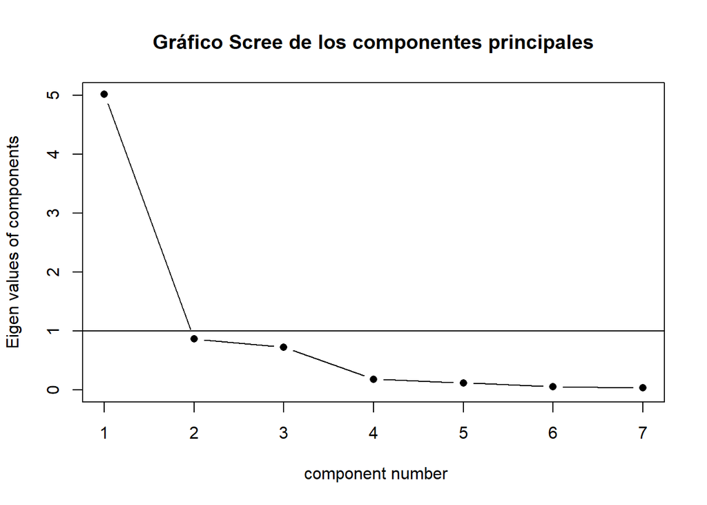

```r
# Criterio de Kaiser
n_kaiser <- sum(autovalores > 1)

# Componentes necesarios para explicar al menos 80%
n_80 <- which(prop_acumulada >= 0.80)[1]

cat("Componentes con autovalor > 1:", n_kaiser, "\n")
```

```
## Componentes con autovalor > 1: 1
```

```r
cat("Componentes para explicar al menos 80%:", n_80, "\n")
```

```
## Componentes para explicar al menos 80%: 2
```

El criterio de Kaiser conservaría únicamente un componente, ya que solamente PC1 tiene un autovalor mayor que 1.

Sin embargo, un solo componente explica 71.581% de la varianza, mientras que los primeros dos explican 83.946%. Por lo tanto, se consideran dos componentes para representar una mayor proporción de la información original.

# 8. Análisis factorial

Se realiza un análisis factorial de dos factores mediante máxima verosimilitud.

Se comparan dos tipos de rotación ortogonal:

- Varimax.
- Quartimax.

```r
n_factores <- 2

# Rotación Varimax
fa_varimax <- psych::fa(
  R,
  nfactors = n_factores,
  n.obs = nrow(M1),
  rotate = "varimax",
  fm = "ml"
)

# Rotación Quartimax
fa_quartimax <- psych::fa(
  R,
  nfactors = n_factores,
  n.obs = nrow(M1),
  rotate = "quartimax",
  fm = "ml"
)

cat("MODELO VARIMAX\n")
```

```
## MODELO VARIMAX
```

```r
print(fa_varimax, cut = 0.30, sort = TRUE)
```

```
## Factor Analysis using method =  ml
## Call: psych::fa(r = R, nfactors = n_factores, n.obs = nrow(M1), rotate = "varimax",
##     fm = "ml")
## Standardized loadings (pattern matrix) based upon correlation matrix
##              item   ML2   ML1   h2    u2 com
## weight          5  0.94       0.92 0.081 1.1
## mileage         3  0.93 -0.33 0.97 0.029 1.2
## cylinders       2  0.91       0.91 0.090 1.2
## mpg             1 -0.80       0.70 0.304 1.2
## horsepower      4  0.79 -0.51 0.89 0.114 1.7
## model_year      7 -0.33       0.16 0.843 1.7
## acceleration    6        0.97 1.00 0.005 1.1
##
##                        ML2  ML1
## SS loadings           4.01 1.53
## Proportion Var        0.57 0.22
## Cumulative Var        0.57 0.79
## Proportion Explained  0.72 0.28
## Cumulative Proportion 0.72 1.00
##
## Mean item complexity =  1.3
## Test of the hypothesis that 2 factors are sufficient.
##
## df null model =  21  with the objective function =  8.91 with Chi Square =  3453.87
## df of  the model are 8  and the objective function was  0.74
##
## The root mean square of the residuals (RMSR) is  0.04
## The df corrected root mean square of the residuals is  0.07
##
## The harmonic n.obs is  392 with the empirical chi square  30.69  with prob <  0.00016
## The total n.obs was  392  with Likelihood Chi Square =  285.83  with prob <  4.3e-57
##
## Tucker Lewis Index of factoring reliability =  0.787
## RMSEA index =  0.298  and the 90 % confidence intervals are  0.269 0.328
## BIC =  238.06
## Fit based upon off diagonal values = 1
## Measures of factor score adequacy
##                                                    ML2  ML1
## Correlation of (regression) scores with factors   0.99 1.00
## Multiple R square of scores with factors          0.98 0.99
## Minimum correlation of possible factor scores     0.96 0.98
```

```r
cat("\nMODELO QUARTIMAX\n")
```

```
##
## MODELO QUARTIMAX
```

```r
print(fa_quartimax, cut = 0.30, sort = TRUE)
```

```
## Factor Analysis using method =  ml
## Call: psych::fa(r = R, nfactors = n_factores, n.obs = nrow(M1), rotate = "quartimax",
##     fm = "ml")
## Standardized loadings (pattern matrix) based upon correlation matrix
##              item   ML2   ML1   h2    u2 com
## mileage         3  0.98       0.97 0.029 1.0
## weight          5  0.96       0.92 0.081 1.0
## cylinders       2  0.95       0.91 0.090 1.0
## horsepower      4  0.90       0.89 0.114 1.2
## mpg             1 -0.83       0.70 0.304 1.0
## model_year      7 -0.38       0.16 0.843 1.2
## acceleration    6 -0.50  0.86 1.00 0.005 1.6
##
##                        ML2  ML1
## SS loadings           4.69 0.84
## Proportion Var        0.67 0.12
## Cumulative Var        0.67 0.79
## Proportion Explained  0.85 0.15
## Cumulative Proportion 0.85 1.00
##
## Mean item complexity =  1.1
## Test of the hypothesis that 2 factors are sufficient.
##
## df null model =  21  with the objective function =  8.91 with Chi Square =  3453.87
## df of  the model are 8  and the objective function was  0.74
##
## The root mean square of the residuals (RMSR) is  0.04
## The df corrected root mean square of the residuals is  0.07
##
## The harmonic n.obs is  392 with the empirical chi square  30.69  with prob <  0.00016
## The total n.obs was  392  with Likelihood Chi Square =  285.83  with prob <  4.3e-57
##
## Tucker Lewis Index of factoring reliability =  0.787
## RMSEA index =  0.298  and the 90 % confidence intervals are  0.269 0.328
## BIC =  238.06
## Fit based upon off diagonal values = 1
## Measures of factor score adequacy
##                                                    ML2  ML1
## Correlation of (regression) scores with factors   0.99 0.99
## Multiple R square of scores with factors          0.98 0.99
## Minimum correlation of possible factor scores     0.97 0.98
```

## Cargas factoriales

```r
# Extraer las cargas
cargas_varimax <- unclass(fa_varimax$loadings)
cargas_quartimax <- unclass(fa_quartimax$loadings)

# Tabla Varimax
tabla_varimax <- data.frame(
  Variable = rownames(cargas_varimax),
  round(cargas_varimax, 3),
  row.names = NULL
)

# Tabla Quartimax
tabla_quartimax <- data.frame(
  Variable = rownames(cargas_quartimax),
  round(cargas_quartimax, 3),
  row.names = NULL
)

knitr::kable(
  tabla_varimax,
  caption = "Cargas factoriales - Varimax"
)
```

Cargas factoriales - Varimax

| Variable | ML2 | ML1 |
| --- | --- | --- |
| mpg | -0.800 | 0.234 |
| cylinders | 0.909 | -0.291 |
| mileage | 0.930 | -0.326 |
| horsepower | 0.790 | -0.512 |
| weight | 0.939 | -0.192 |
| acceleration | -0.246 | 0.967 |
| model_year | -0.331 | 0.217 |

```r
knitr::kable(
  tabla_quartimax,
  caption = "Cargas factoriales - Quartimax"
)
```

Cargas factoriales - Quartimax

| Variable | ML2 | ML1 |
| --- | --- | --- |
| mpg | -0.834 | 0.007 |
| cylinders | 0.954 | -0.031 |
| mileage | 0.984 | -0.059 |
| horsepower | 0.900 | -0.276 |
| weight | 0.956 | 0.072 |
| acceleration | -0.501 | 0.863 |
| model_year | -0.378 | 0.118 |

Con Varimax, un factor presenta cargas altas en `weight` (0.939), `mileage` (0.930), `cylinders` (0.909), `horsepower` (0.790) y una carga negativa alta en `mpg` (-0.800).

El otro factor está principalmente asociado con `acceleration`, cuya carga es 0.967.

Quartimax produce una estructura parecida: `mileage`, `weight`, `cylinders` y `horsepower` se concentran principalmente en un factor, mientras que `acceleration` tiene su mayor carga en el segundo.

Por su separación más clara de `acceleration` respecto a las demás variables, se utilizará la rotación Varimax para describir los factores.

## Comunalidades

Las comunalidades representan la proporción de la variabilidad de cada variable que puede ser explicada por los factores obtenidos.

```r
tabla_comunalidades <- data.frame(
  Variable = rownames(cargas_varimax),
  Comunalidad = fa_varimax$communality,
  Unicidad = fa_varimax$uniquenesses
)

knitr::kable(
  tabla_comunalidades,
  digits = 3,
  caption = "Comunalidades y unicidades - Varimax"
)
```

Comunalidades y unicidades - Varimax

|  | Variable | Comunalidad | Unicidad |
| --- | --- | --- | --- |
| mpg | mpg | 0.696 | 0.304 |
| cylinders | cylinders | 0.910 | 0.090 |
| mileage | mileage | 0.971 | 0.029 |
| horsepower | horsepower | 0.886 | 0.114 |
| weight | weight | 0.919 | 0.081 |
| acceleration | acceleration | 0.995 | 0.005 |
| model_year | model_year | 0.157 | 0.843 |

La mayoría de las variables son bien representadas por los dos factores. Por ejemplo, `acceleration` tiene una comunalidad de 0.995, `mileage` de 0.971 y `weight` de 0.919.

En cambio, `model_year` tiene una comunalidad de solo 0.157, por lo que los dos factores explican poco de su variabilidad.

# 9. Composiciones lineales e identificación de los factores

Utilizando las cargas de la rotación Varimax, las variables estandarizadas se pueden expresar aproximadamente en función de los dos factores de la siguiente manera:

$$Z_{mpg}=-0.800F_1+0.234F_2+e_{mpg}$$

$$Z_{cylinders}=0.909F_1-0.291F_2+e_{cylinders}$$

$$Z_{mileage}=0.930F_1-0.326F_2+e_{mileage}$$

$$Z_{horsepower}=0.790F_1-0.512F_2+e_{horsepower}$$

$$Z_{weight}=0.939F_1-0.192F_2+e_{weight}$$

$$Z_{acceleration}=-0.246F_1+0.967F_2+e_{acceleration}$$

$$Z_{model\_year}=-0.331F_1+0.217F_2+e_{model\_year}$$

El primer factor está principalmente relacionado con `weight`, `mileage`, `cylinders` y `horsepower`, además de presentar una relación negativa con `mpg`. Por ello, puede interpretarse como un factor relacionado con las características físicas, potencia y consumo del automóvil.

El segundo factor está dominado por `acceleration`, con una carga de 0.967, por lo que puede interpretarse principalmente como un factor relacionado con la aceleración.

`model_year` presenta cargas pequeñas en ambos factores, lo cual coincide con su baja comunalidad y muestra que no queda bien representada por esta estructura de dos factores.

# 10. Diferencias entre Componentes Principales y Análisis Factorial

El análisis de componentes principales y el análisis factorial buscan representar varias variables mediante un menor número de dimensiones, pero sus objetivos son diferentes.

El análisis de componentes principales utiliza la varianza total de las variables y construye componentes que buscan explicar la mayor cantidad posible de esa variabilidad. Se utiliza principalmente para reducir la dimensionalidad de los datos.

El análisis factorial busca explicar las correlaciones y la varianza común entre las variables mediante factores latentes. Además, reconoce que existe una parte de cada variable que no es explicada por los factores comunes.

Por lo tanto, componentes principales se enfoca principalmente en reducir el número de variables, mientras que el análisis factorial busca encontrar factores subyacentes que expliquen las relaciones entre ellas.

# Declaratoria de uso de Inteligencia Artificial

Para la realización de esta actividad se utilizó ChatGPT como herramienta de apoyo para estructurar el código en R, revisar la sintaxis, organizar el procedimiento estadístico y apoyar en la interpretación de los resultados. La ejecución del análisis, revisión de los resultados y elaboración final de la actividad fueron supervisadas y validadas por mí.